# chapter4.Rmd

Henrik Wejberg

2022-11-28

```
## 'data.frame':    506 obs. of  14 variables:
##  $ crim   : num  0.00632 0.02731 0.02729 0.03237 0.06905 ...
##  $ zn     : num  18 0 0 0 0 0 12.5 12.5 12.5 12.5 ...
##  $ indus  : num  2.31 7.07 7.07 2.18 2.18 2.18 7.87 7.87 7.87 7.87 ...
##  $ chas   : int  0 0 0 0 0 0 0 0 0 0 ...
##  $ nox    : num  0.538 0.469 0.469 0.458 0.458 0.458 0.524 0.524 0.524 0.524 ...
##  $ rm     : num  6.58 6.42 7.18 7 7.15 ...
##  $ age    : num  65.2 78.9 61.1 45.8 54.2 58.7 66.6 96.1 100 85.9 ...
##  $ dis    : num  4.09 4.97 4.97 6.06 6.06 ...
##  $ rad    : int  1 2 2 3 3 3 5 5 5 5 ...
##  $ tax    : num  296 242 242 222 222 222 311 311 311 311 ...
##  $ ptratio: num  15.3 17.8 17.8 18.7 18.7 18.7 15.2 15.2 15.2 15.2 ...
##  $ black  : num  397 397 393 395 397 ...
##  $ lstat  : num  4.98 9.14 4.03 2.94 5.33 ...
##  $ medv   : num  24 21.6 34.7 33.4 36.2 28.7 22.9 27.1 16.5 18.9 ...
```

```
## [1] 506  14
```

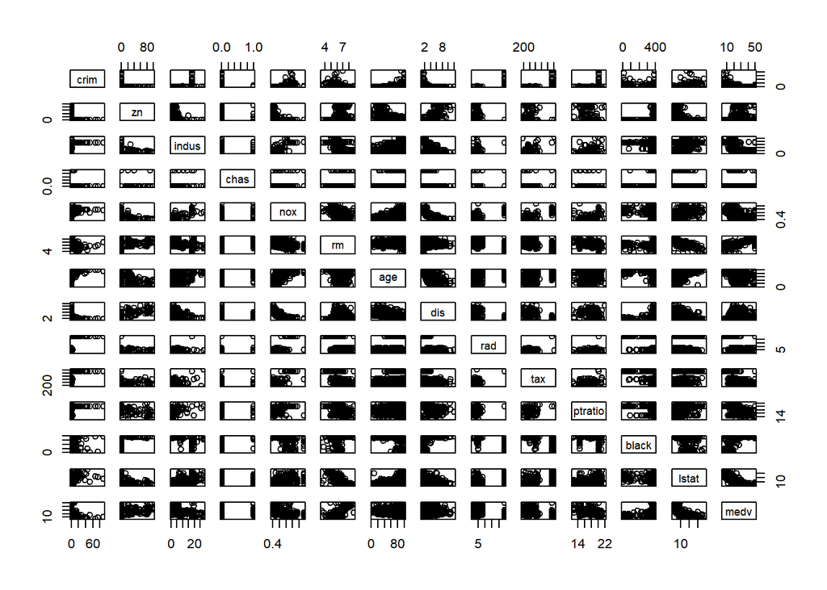

Boston dataset has 14 variables and 506 observations. They are the following, found through [this link](https://www.cs.toronto.edu/~delve/data/boston/bostonDetail.html):

CRIM - per capita crime rate by town ZN - proportion of residential land zoned for lots over 25,000 sq.ft. INDUS - proportion of non-retail business acres per town. CHAS - Charles River dummy variable (1 if tract bounds river; 0 otherwise) NOX - nitric oxides concentration (parts per 10 million) RM - average number of rooms per dwelling AGE - proportion of owner-occupied units built prior to 1940 DIS - weighted distances to five Boston employment centres RAD - index of accessibility to radial highways TAX - full-value property-tax rate per $10,000 PTRATIO - pupil-teacher ratio by town B - 1000(Bk - 0.63)^2 where Bk is the proportion of blacks by town LSTAT - % lower status of the population MEDV - Median value of owner-occupied homes in $1000’s

This data can be used to analyse how the different variables affect each other. For example, how does crime and location affect median values of homes?

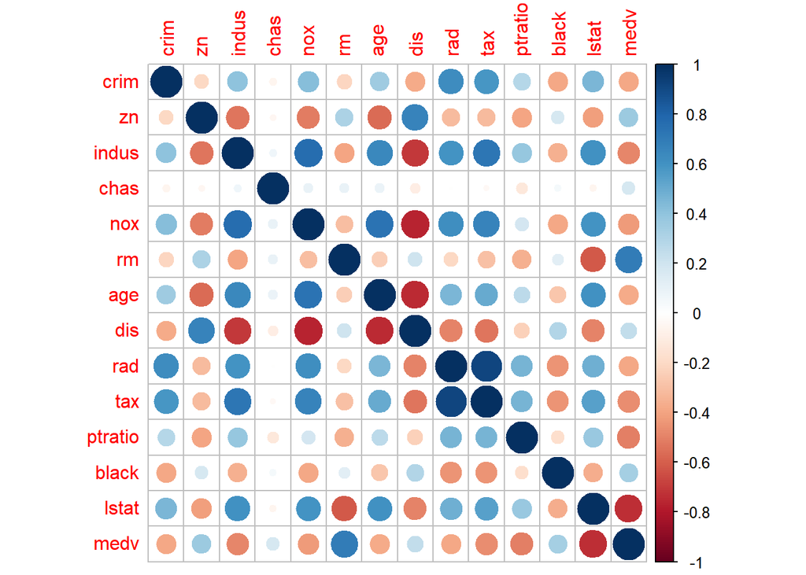

```
##       crim                zn             indus            chas
##  Min.   : 0.00632   Min.   :  0.00   Min.   : 0.46   Min.   :0.00000
##  1st Qu.: 0.08205   1st Qu.:  0.00   1st Qu.: 5.19   1st Qu.:0.00000
##  Median : 0.25651   Median :  0.00   Median : 9.69   Median :0.00000
##  Mean   : 3.61352   Mean   : 11.36   Mean   :11.14   Mean   :0.06917
##  3rd Qu.: 3.67708   3rd Qu.: 12.50   3rd Qu.:18.10   3rd Qu.:0.00000
##  Max.   :88.97620   Max.   :100.00   Max.   :27.74   Max.   :1.00000
##       nox               rm             age              dis
##  Min.   :0.3850   Min.   :3.561   Min.   :  2.90   Min.   : 1.130
##  1st Qu.:0.4490   1st Qu.:5.886   1st Qu.: 45.02   1st Qu.: 2.100
##  Median :0.5380   Median :6.208   Median : 77.50   Median : 3.207
##  Mean   :0.5547   Mean   :6.285   Mean   : 68.57   Mean   : 3.795
##  3rd Qu.:0.6240   3rd Qu.:6.623   3rd Qu.: 94.08   3rd Qu.: 5.188
##  Max.   :0.8710   Max.   :8.780   Max.   :100.00   Max.   :12.127
##       rad              tax           ptratio          black
##  Min.   : 1.000   Min.   :187.0   Min.   :12.60   Min.   :  0.32
##  1st Qu.: 4.000   1st Qu.:279.0   1st Qu.:17.40   1st Qu.:375.38
##  Median : 5.000   Median :330.0   Median :19.05   Median :391.44
##  Mean   : 9.549   Mean   :408.2   Mean   :18.46   Mean   :356.67
##  3rd Qu.:24.000   3rd Qu.:666.0   3rd Qu.:20.20   3rd Qu.:396.23
##  Max.   :24.000   Max.   :711.0   Max.   :22.00   Max.   :396.90
##      lstat            medv
##  Min.   : 1.73   Min.   : 5.00
##  1st Qu.: 6.95   1st Qu.:17.02
##  Median :11.36   Median :21.20
##  Mean   :12.65   Mean   :22.53
##  3rd Qu.:16.95   3rd Qu.:25.00
##  Max.   :37.97   Max.   :50.00
```

```
##       crim                 zn               indus              chas
##  Min.   :-0.419367   Min.   :-0.48724   Min.   :-1.5563   Min.   :-0.2723
##  1st Qu.:-0.410563   1st Qu.:-0.48724   1st Qu.:-0.8668   1st Qu.:-0.2723
##  Median :-0.390280   Median :-0.48724   Median :-0.2109   Median :-0.2723
##  Mean   : 0.000000   Mean   : 0.00000   Mean   : 0.0000   Mean   : 0.0000
##  3rd Qu.: 0.007389   3rd Qu.: 0.04872   3rd Qu.: 1.0150   3rd Qu.:-0.2723
##  Max.   : 9.924110   Max.   : 3.80047   Max.   : 2.4202   Max.   : 3.6648
##       nox                rm               age               dis
##  Min.   :-1.4644   Min.   :-3.8764   Min.   :-2.3331   Min.   :-1.2658
##  1st Qu.:-0.9121   1st Qu.:-0.5681   1st Qu.:-0.8366   1st Qu.:-0.8049
##  Median :-0.1441   Median :-0.1084   Median : 0.3171   Median :-0.2790
##  Mean   : 0.0000   Mean   : 0.0000   Mean   : 0.0000   Mean   : 0.0000
##  3rd Qu.: 0.5981   3rd Qu.: 0.4823   3rd Qu.: 0.9059   3rd Qu.: 0.6617
##  Max.   : 2.7296   Max.   : 3.5515   Max.   : 1.1164   Max.   : 3.9566
##       rad               tax             ptratio            black
##  Min.   :-0.9819   Min.   :-1.3127   Min.   :-2.7047   Min.   :-3.9033
##  1st Qu.:-0.6373   1st Qu.:-0.7668   1st Qu.:-0.4876   1st Qu.: 0.2049
##  Median :-0.5225   Median :-0.4642   Median : 0.2746   Median : 0.3808
##  Mean   : 0.0000   Mean   : 0.0000   Mean   : 0.0000   Mean   : 0.0000
##  3rd Qu.: 1.6596   3rd Qu.: 1.5294   3rd Qu.: 0.8058   3rd Qu.: 0.4332
##  Max.   : 1.6596   Max.   : 1.7964   Max.   : 1.6372   Max.   : 0.4406
##      lstat              medv
##  Min.   :-1.5296   Min.   :-1.9063
##  1st Qu.:-0.7986   1st Qu.:-0.5989
##  Median :-0.1811   Median :-0.1449
##  Mean   : 0.0000   Mean   : 0.0000
##  3rd Qu.: 0.6024   3rd Qu.: 0.2683
##  Max.   : 3.5453   Max.   : 2.9865
```

```
## [1] "matrix" "array"
```

```
##      Min.   1st Qu.    Median      Mean   3rd Qu.      Max.
## -0.419367 -0.410563 -0.390280  0.000000  0.007389  9.924110
```

```
##           0%          25%          50%          75%         100%
## -0.419366929 -0.410563278 -0.390280295  0.007389247  9.924109610
```

```
## crime
## [-0.419,-0.411]  (-0.411,-0.39] (-0.39,0.00739]  (0.00739,9.92]
##             127             126             126             127
```

We scaled the data so every variable would have a mean of 0. This is done by subtracting from every observation the variable mean of the same variable and dividing by the variables standard deviation. After this, as previously said, all variables have a mean of 0 and all variables have also negative values. Compared to pre-scaling, there wasn’t every negative values since home values cannot be negative.

The later outputs show that we created quantiles for crime. All the observations have been divided equally to four groups, where crime rates differ inside the groups. The last two groups, which also have the most crime, has much more variance than the previous two, which can be seen from the “edge” values of the groups.

Training and test groups were also created by sampling 80 % of the data to training set and 20 % to test set.

```
## Call:
## lda(crime ~ ., data = train)
##
## Prior probabilities of groups:
## [-0.419,-0.411]  (-0.411,-0.39] (-0.39,0.00739]  (0.00739,9.92]
##       0.2524752       0.2574257       0.2574257       0.2326733
##
## Group means:
##                          zn      indus        chas        nox         rm
## [-0.419,-0.411]  0.96869081 -0.9116913 -0.11793298 -0.8796629  0.4038583
## (-0.411,-0.39]  -0.08485475 -0.2754329 -0.04518867 -0.5441984 -0.1656167
## (-0.39,0.00739] -0.37839823  0.1484211  0.18195173  0.3190295  0.1713378
## (0.00739,9.92]  -0.48724019  1.0172896 -0.10479289  0.9983624 -0.4704089
##                        age        dis        rad        tax     ptratio
## [-0.419,-0.411] -0.8928512  0.9034884 -0.6812431 -0.7237127 -0.42596927
## (-0.411,-0.39]  -0.3016551  0.3482187 -0.5445703 -0.4865776 -0.05851761
## (-0.39,0.00739]  0.4147627 -0.3758623 -0.4021162 -0.3211838 -0.30190622
## (0.00739,9.92]   0.7880064 -0.8467069  1.6363892  1.5128120  0.77875205
##                       black       lstat        medv
## [-0.419,-0.411]  0.38465630 -0.76257742  0.47324546
## (-0.411,-0.39]   0.31678847 -0.09135759 -0.02782215
## (-0.39,0.00739]  0.08831177 -0.01454020  0.22779761
## (0.00739,9.92]  -0.84454064  0.86503329 -0.68902794
##
## Coefficients of linear discriminants:
##                 LD1         LD2         LD3
## zn       0.08733107  0.74410225 -0.89094134
## indus    0.06278047 -0.21197990  0.32723513
## chas    -0.09605847 -0.08870793 -0.02595371
## nox      0.33779189 -0.72324210 -1.31887515
## rm      -0.10568202 -0.12591783 -0.22219647
## age      0.23877837 -0.28708188 -0.14375387
## dis     -0.06282544 -0.25217513  0.20814131
## rad      3.14178580  0.92412372 -0.06894409
## tax      0.02629697 -0.01771382  0.43271013
## ptratio  0.10478544 -0.03863491 -0.20839875
## black   -0.14375235  0.01606993  0.08452861
## lstat    0.24115660 -0.31103881  0.45444382
## medv     0.19711850 -0.48927593 -0.09870073
##
## Proportion of trace:
##    LD1    LD2    LD3
## 0.9459 0.0413 0.0127
```

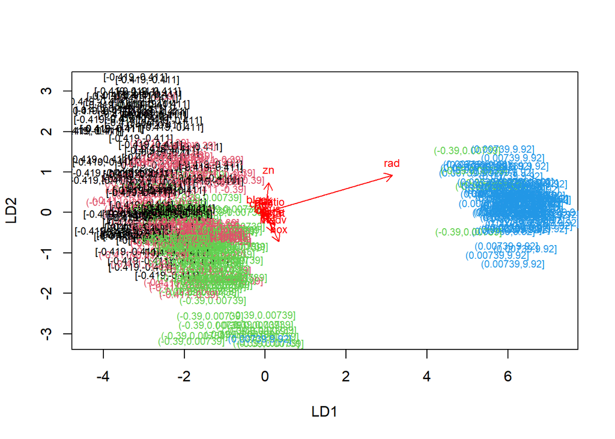

We use the training set to conduct linear discriminant analysis. We choose crime rate as target variable and assign all other variables in the training set as predictor variables. In group means we see what the mean values of other variables are in certain quantiles of crime levels. From the lda plot, we can see quite clearly that the areas can be divided to two groups based on the crime rate in different areas.

```
##                  predicted
## correct           [-0.419,-0.411] (-0.411,-0.39] (-0.39,0.00739] (0.00739,9.92]
##   [-0.419,-0.411]              12             10               3              0
##   (-0.411,-0.39]                5             14               3              0
##   (-0.39,0.00739]               0              7              14              1
##   (0.00739,9.92]                0              0               0             33
```

```
##    Min. 1st Qu.  Median    Mean 3rd Qu.    Max.
##  0.1343  3.4625  4.8241  4.9111  6.1863 14.3970
```

```
##    Min. 1st Qu.  Median    Mean 3rd Qu.    Max.
##  0.2662  8.4832 12.6090 13.5488 17.7568 48.8618
```

```
##    Min. 1st Qu.  Median    Mean 3rd Qu.    Max.
##  0.1343  3.4625  4.8241  4.9111  6.1863 14.3970
```

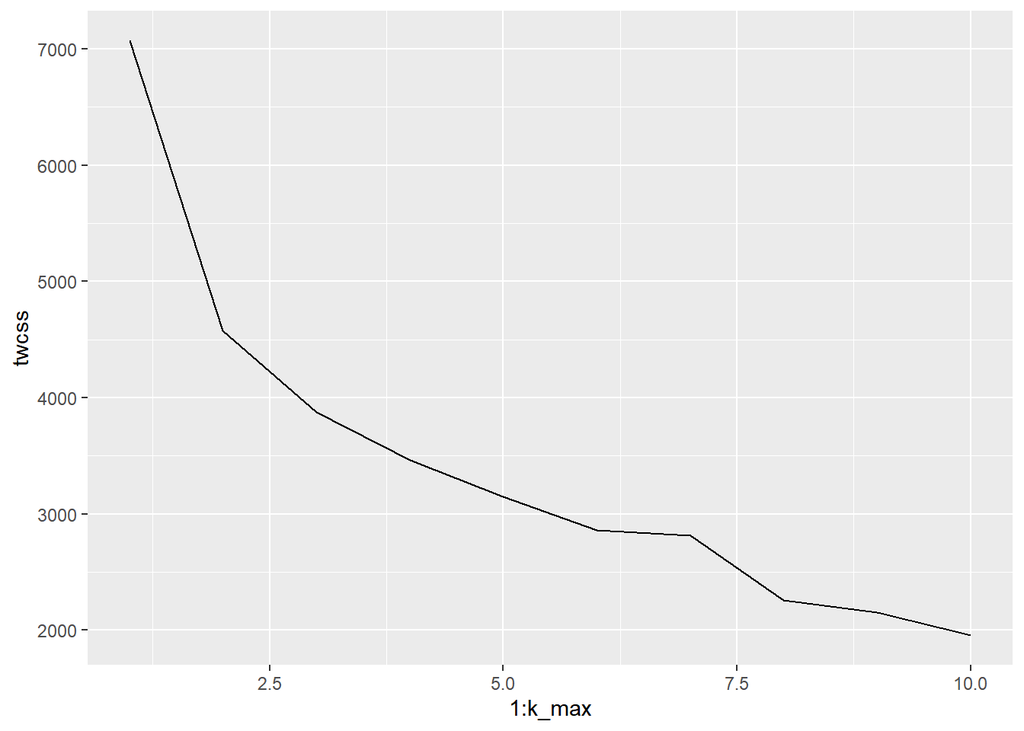

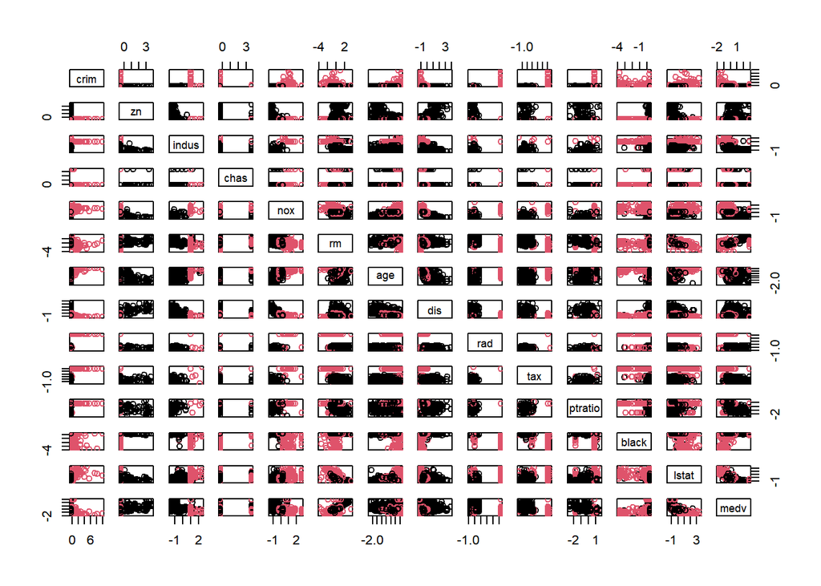

We calculated the total within sum of squares. From the literature we know that when the sum of squares drastically changes after changing the number of groups, we should choose the number of groups were the drastic change happened. The greatest reduction is between 1:2, so we decided to use two groups.

From the second plot we can see how all the variables are divided to two groups. In most of the pairs, the red and black observations are clearly separated from each other. Based on this visual confirmation, we can say that the k-means groups increases our understanding of the data and help us make predictions.